# Alternative analysis of postural sway data

This program runs some alternatives to the two-sample t-test. Consult the [data dictionary](https://github.com/pmean/data/blob/main/files/postural-sway.yaml) for information about the data itself.

## Libraries

```r
library(tidyverse)
```

## Read data

```r
sway <- read_tsv(
  file="../data/postural-sway.txt",
  col_types="cnn")
names(sway) <- tolower(names(sway))
glimpse(sway)
```

```
Rows: 17
Columns: 3
$ age      <chr> "Elderly", "Elderly", "Elderly", "Elderly", "Elderly", "Elder…
$ fbsway   <dbl> 19, 30, 20, 19, 29, 25, 21, 24, 50, 25, 21, 17, 15, 14, 14, 2…
$ sidesway <dbl> 14, 41, 18, 11, 16, 24, 18, 21, 37, 17, 10, 16, 22, 12, 14, 1…
```

## Question 1

The side-to-side sway data appears to have a pair of outliers and some evidence of heterogenity. Use a log transformation to see if this makes things better. Analyze the data on a log scale using a two-sample t-test and report the confidence interval after transforming back to the original scale of measurement.

## Boxplot of side-to-side sway by age

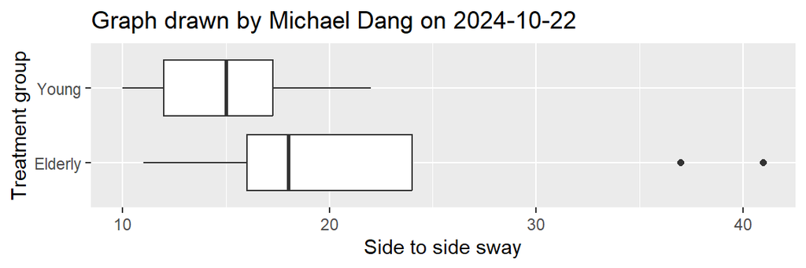

```r
sway |>
  ggplot(aes(age, sidesway)) +
    geom_boxplot() +
    ggtitle("Graph drawn by Michael Dang on 2024-10-22") +
    xlab("Treatment group") +
    ylab("Side to side sway") +
    coord_flip()
```

The outlier causes some concern about the validity of the two-sample t-test.

## Descriptive statistics for side-to-side sway by age

```r
sway |>
  group_by(age) |>
  summarize(
    sts_mn=mean(sidesway),
    sts_sd=sd(sidesway),
    n=n())
```

```
# A tibble: 2 × 4
  age     sts_mn sts_sd     n
  <chr>    <dbl>  <dbl> <int>
1 Elderly   22.2  10.3      9
2 Young     15.1   3.91     8
```

In addition to the outlier, notice that the group with the larger mean (elderly) has the larger standard deviation. This indicates that a log transformation may produce better results.

## Log transformation, 1

```r
sway |>
  mutate(log_sidesway=log10(sidesway)) -> log_sway
```

## Log transformation, 2

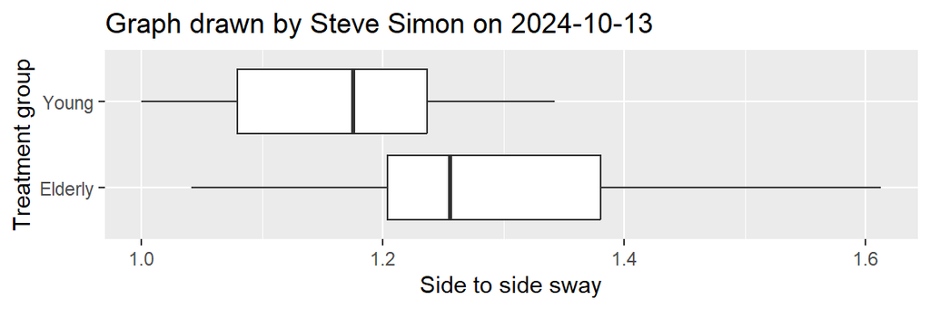

```r
log_sway |>
  ggplot(aes(age, log_sidesway)) +
    geom_boxplot() +
    ggtitle("Graph drawn by Steve Simon on 2024-10-13") +
    xlab("Treatment group") +
    ylab("Side to side sway") +
    coord_flip()
```

There are no outliers after a log transformation.

## Log transformation, 3

```r
log_sway |>
  group_by(age) |>
  summarize(
    log_mn=mean(log_sidesway),
    log_sd=sd(log_sidesway),
    n=n())
```

```
# A tibble: 2 × 4
  age     log_mn log_sd     n
  <chr>    <dbl>  <dbl> <int>
1 Elderly   1.31  0.187     9
2 Young     1.17  0.112     8
```

The standard deviations on the log scale are quite a bit more similar than they were on the original scale.

## Two-sample t-test using the log transformation

```r
m2 <- t.test(
  log_sidesway ~ age,
  data=log_sway,
  alternative="two.sided",
  var.equal=TRUE)
m2
```

```
    Two Sample t-test

data:  log_sidesway by age
t = 1.8729, df = 15, p-value = 0.08071
alternative hypothesis: true difference in means between group Elderly and group Young is not equal to 0
95 percent confidence interval:
 -0.01966132  0.30449529
sample estimates:
mean in group Elderly   mean in group Young
             1.309511              1.167094
```

## Back-transform confidence interval to the original scale.

```r
10^(m2$conf.int)
```

```
[1] 0.9557376 2.0160221
attr(,"conf.level")
[1] 0.95
```

We are 95% confident that the geometric mean side-to-side sway in elderly patients is somewhere between 0.96 times and 2.02 times that of the geometric mean for young patients. This suggests that there is no statistically significant difference between the groups, as the interval includes values below 1, which implies that the sway in elderly patients could potentially be lower than that in younger patients.

## Mann-Whitney-Wilcoxon

```r
wilcox.test(sidesway ~ age, data=sway)
```

```
    Wilcoxon rank sum test with continuity correction

data:  sidesway by age
W = 53, p-value = 0.1108
alternative hypothesis: true location shift is not equal to 0
```

## Question 2

You want to replicate these findings in a new population, using the log transformation on the new data. Select a standard deviation from log transformed side-to-side sway values in the current study (go halfway between the two standard deviations). You want to have 90% power for detecting a 1.5 fold change (which is 0.176 units on a log base 10 scale). If you use a two-sided hypothesis with alpha = 0.05, what sample size would you need?

```r
power.t.test(
  n=NULL,
  delta=0.176,
  sd=0.149, # (0.1119424 + 0.1869584) / 2
  sig.level=0.05,
  power=0.9,
  type="two.sample",
  alternative="two.sided")
```

```
     Two-sample t test power calculation

              n = 16.08571
          delta = 0.176
             sd = 0.149
      sig.level = 0.05
          power = 0.9
    alternative = two.sided

NOTE: n is number in *each* group
```